# Problem Set 3

This assignment is the first part of problem set 3 of the Udacity course *Data Analysis with R* lesson 3: *Explore One Variable*. This part of the problem set consists in a set of questions/tasks answered below.

### Diamonds

Load the diamonds dataset.

```r
library(ggplot2)
data(diamonds)
?diamonds

str(diamonds)
```

```
## 'data.frame':    53940 obs. of  10 variables:
##  $ carat  : num  0.23 0.21 0.23 0.29 0.31 0.24 0.24 0.26 0.22 0.23 ...
##  $ cut    : Ord.factor w/ 5 levels "Fair"<"Good"<..: 5 4 2 4 2 3 3 3 1 3 ...
##  $ color  : Ord.factor w/ 7 levels "D"<"E"<"F"<"G"<..: 2 2 2 6 7 7 6 5 2 5 ...
##  $ clarity: Ord.factor w/ 8 levels "I1"<"SI2"<"SI1"<..: 2 3 5 4 2 6 7 3 4 5 ...
##  $ depth  : num  61.5 59.8 56.9 62.4 63.3 62.8 62.3 61.9 65.1 59.4 ...
##  $ table  : num  55 61 65 58 58 57 57 55 61 61 ...
##  $ price  : int  326 326 327 334 335 336 336 337 337 338 ...
##  $ x      : num  3.95 3.89 4.05 4.2 4.34 3.94 3.95 4.07 3.87 4 ...
##  $ y      : num  3.98 3.84 4.07 4.23 4.35 3.96 3.98 4.11 3.78 4.05 ...
##  $ z      : num  2.43 2.31 2.31 2.63 2.75 2.48 2.47 2.53 2.49 2.39 ...
```

#### How many observations are in the dataset?

53940

#### How many variables ?

10

#### How many ordered factors are in the dataset?

3

#### What letter represents the best color for a diamond?

D

### Price Histogram

Create a histogram of the price of all the diamonds in the diamond data set.

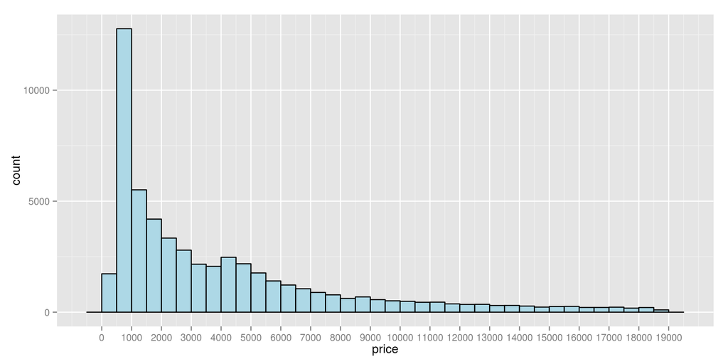

```r
qplot(x = price, data = diamonds, binwidth = 500,
      color = I('black'), fill = I('light blue')) +
  scale_x_continuous(breaks = seq(0,19000, 1000))
```

#### Describe the shape and center of the price distribution.

The distribution is right-skewed and presents a long tail. In such a distribution, the *median* is often a better representation of the center price of the diamonds then the *mean*.

```r
summary(diamonds$price)
```

```
##    Min. 1st Qu.  Median    Mean 3rd Qu.    Max.
##     326     950    2401    3933    5324   18820
```

### Diamonds Count

#### How many diamonds cost less than $500?

```r
dim(subset(diamonds, price < 500))[1]
```

```
## [1] 1729
```

#### How many diamonds cost less than $250?

```r
dim(subset(diamonds, price < 250))[1]
```

```
## [1] 0
```

#### How many diamonds cost $15,000 or more?

```r
dim(subset(diamonds, price >= 15000))[1]
```

```
## [1] 1656
```

### Cheaper Diamonds

Explore the largest peak in the price histogram you created earlier. Try limiting the x-axis, altering the bin width, and setting different breaks on the x-axis.

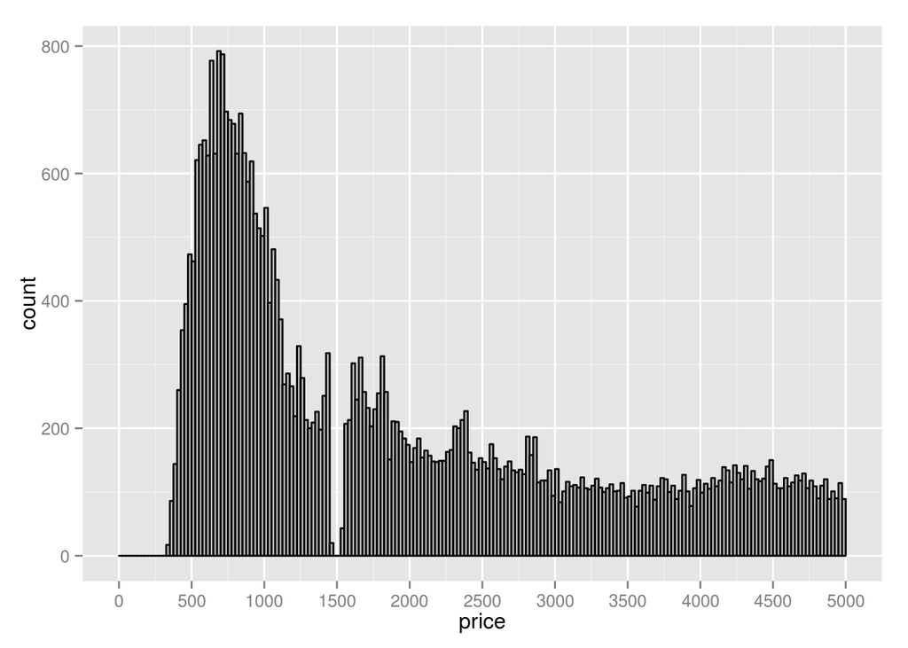

```r
qplot(x = price, data = diamonds, binwidth = 25,
      color = I('black'), fill = I('grey')) +
  scale_x_continuous(breaks=seq(0,5000, 500), limits=c(0,5000))
```

The largest peak seems to be in the [300, 1500] interval.

```r
library(gridExtra)
```

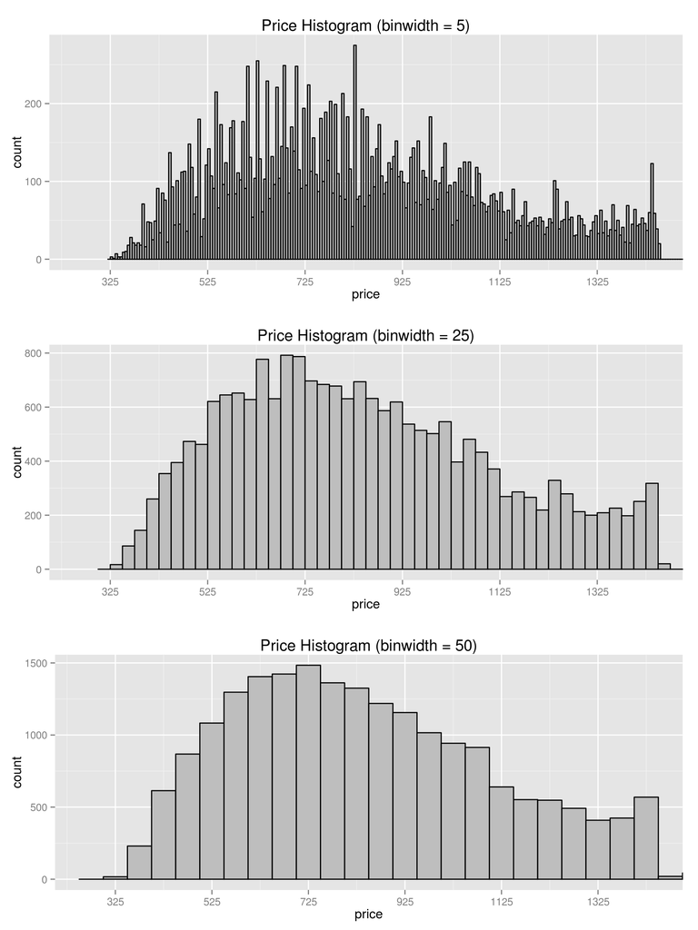

```r
p1 <- qplot(x = price, data = diamonds, binwidth = 5,
      color = I('black'), fill = I('grey'),
      main = "Price Histogram (binwidth = 5)") +
  scale_x_continuous(breaks=seq(325,1500, 200)) +
  coord_cartesian(xlim = c(200,1500))

p2 <- qplot(x = price, data = diamonds, binwidth = 25,
      color = I('black'), fill = I('grey'),
      main = "Price Histogram (binwidth = 25)") +
  scale_x_continuous(breaks=seq(325,1500, 200)) +
  coord_cartesian(xlim = c(200,1500))

p3 <- qplot(x = price, data = diamonds, binwidth = 50,
      color = I('black'), fill = I('grey'),
      main = "Price Histogram (binwidth = 50)") +
  scale_x_continuous(breaks=seq(325,1500, 200)) +
  coord_cartesian(xlim = c(200,1500))

grid.arrange(p1,p2,p3)
```

Smaller bin-widths of 5, for example, result in a very “noisy” histogram that is difficult to read. Bin-widths of 25 and 50 are a better choice for a smoother and easy to read histogram.

```r
summary(subset(diamonds$price, diamonds$price > 325 & diamonds$price <=1500))
```

```
##    Min. 1st Qu.  Median    Mean 3rd Qu.    Max.
##   326.0   630.0   805.0   841.4  1024.0  1454.0
```

No diamonds cost 1500.

### Price by Cut

#### Histograms

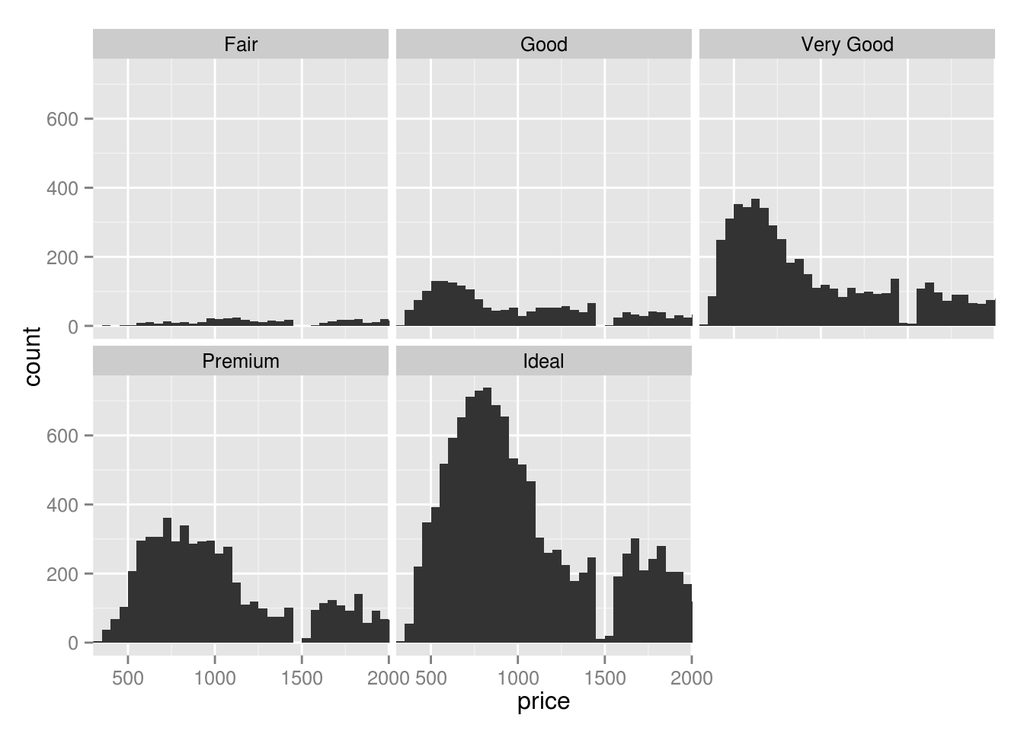

```r
qplot(x = price, data = diamonds, binwidth = 50)+
  facet_wrap(~cut) +
  coord_cartesian(xlim = c(300, 2000))
```

#### Which cut has the highest priced diamond ?

Premium

```r
by(diamonds$price, diamonds$cut, max)
```

```
## diamonds$cut: Fair
## [1] 18574
## --------------------------------------------------------
## diamonds$cut: Good
## [1] 18788
## --------------------------------------------------------
## diamonds$cut: Very Good
## [1] 18818
## --------------------------------------------------------
## diamonds$cut: Premium
## [1] 18823
## --------------------------------------------------------
## diamonds$cut: Ideal
## [1] 18806
```

#### Which cut has the lowest priced diamond ?

Premium, Ideal

```r
by(diamonds$price, diamonds$cut, min)
```

```
## diamonds$cut: Fair
## [1] 337
## --------------------------------------------------------
## diamonds$cut: Good
## [1] 327
## --------------------------------------------------------
## diamonds$cut: Very Good
## [1] 336
## --------------------------------------------------------
## diamonds$cut: Premium
## [1] 326
## --------------------------------------------------------
## diamonds$cut: Ideal
## [1] 326
```

#### Which cut has the lowest median price ?

Ideal

```r
by(diamonds$price, diamonds$cut, median)
```

```
## diamonds$cut: Fair
## [1] 3282
## --------------------------------------------------------
## diamonds$cut: Good
## [1] 3050.5
## --------------------------------------------------------
## diamonds$cut: Very Good
## [1] 2648
## --------------------------------------------------------
## diamonds$cut: Premium
## [1] 3185
## --------------------------------------------------------
## diamonds$cut: Ideal
## [1] 1810
```

Note: the summary presents different results for some of these values. Example: max.

```r
by(diamonds$price, diamonds$cut, summary)
```

```
## diamonds$cut: Fair
##    Min. 1st Qu.  Median    Mean 3rd Qu.    Max.
##     337    2050    3282    4359    5206   18570
## --------------------------------------------------------
## diamonds$cut: Good
##    Min. 1st Qu.  Median    Mean 3rd Qu.    Max.
##     327    1145    3050    3929    5028   18790
## --------------------------------------------------------
## diamonds$cut: Very Good
##    Min. 1st Qu.  Median    Mean 3rd Qu.    Max.
##     336     912    2648    3982    5373   18820
## --------------------------------------------------------
## diamonds$cut: Premium
##    Min. 1st Qu.  Median    Mean 3rd Qu.    Max.
##     326    1046    3185    4584    6296   18820
## --------------------------------------------------------
## diamonds$cut: Ideal
##    Min. 1st Qu.  Median    Mean 3rd Qu.    Max.
##     326     878    1810    3458    4678   18810
```

### Scales and Multiple Histograms

Looking at the summary, the distributions should be somewhat similar, but the previous histograms created don’t show that.  
Make scales free for histograms with *facet_warp*.

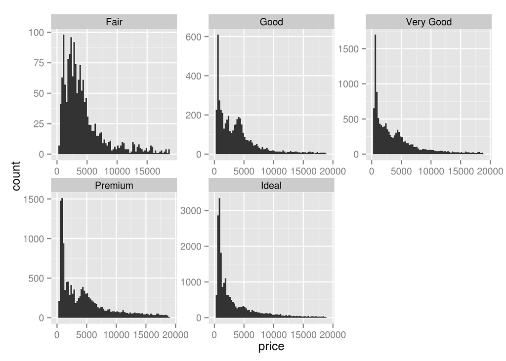

```r
qplot(x = price, data = diamonds, binwidth=250) +
  facet_wrap(~cut, scales = 'free')
```

### Price per Carat by Cut

Create a histogram of price per carat and facet it by cut. Adjust the bin width and transform the scale of the x-axis using log10.

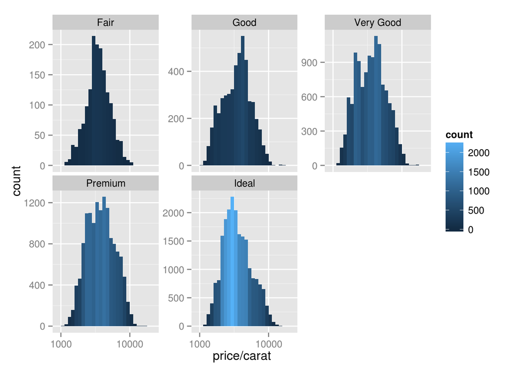

```r
qplot(x = price/carat, data = diamonds, binwidth = .05,
      fill=..count..) +
  facet_wrap(~cut, scales='free_y') +
  scale_x_log10()
```

### Price Box Plots

Investigate the price of diamonds using box plots, numerical summaries, and one of the following categorical variables: cut, clarity, or color.

#### Color

```r
by(diamonds$price, diamonds$color, summary)
```

```
## diamonds$color: D
##    Min. 1st Qu.  Median    Mean 3rd Qu.    Max.
##     357     911    1838    3170    4214   18690
## --------------------------------------------------------
## diamonds$color: E
##    Min. 1st Qu.  Median    Mean 3rd Qu.    Max.
##     326     882    1739    3077    4003   18730
## --------------------------------------------------------
## diamonds$color: F
##    Min. 1st Qu.  Median    Mean 3rd Qu.    Max.
##     342     982    2344    3725    4868   18790
## --------------------------------------------------------
## diamonds$color: G
##    Min. 1st Qu.  Median    Mean 3rd Qu.    Max.
##     354     931    2242    3999    6048   18820
## --------------------------------------------------------
## diamonds$color: H
##    Min. 1st Qu.  Median    Mean 3rd Qu.    Max.
##     337     984    3460    4487    5980   18800
## --------------------------------------------------------
## diamonds$color: I
##    Min. 1st Qu.  Median    Mean 3rd Qu.    Max.
##     334    1120    3730    5092    7202   18820
## --------------------------------------------------------
## diamonds$color: J
##    Min. 1st Qu.  Median    Mean 3rd Qu.    Max.
##     335    1860    4234    5324    7695   18710
```

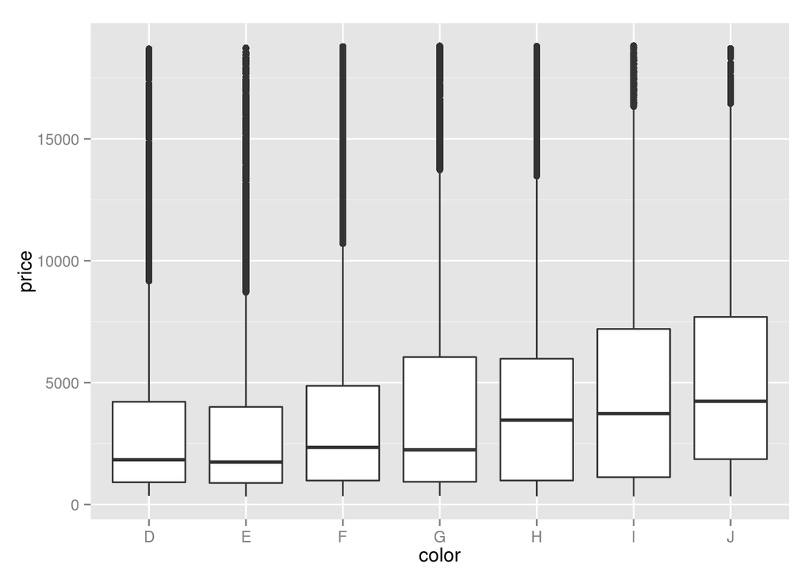

```r
qplot(x = color, y = price, data = diamonds,
      geom = 'boxplot')
```

The prices seem to be higher for the J (worst) color. =/  
Perhaps a price/carat analysis would be more accurate.

### Interquartile Range - IQR

```r
by(diamonds$price, diamonds$color, summary)
```

```
## diamonds$color: D
##    Min. 1st Qu.  Median    Mean 3rd Qu.    Max.
##     357     911    1838    3170    4214   18690
## --------------------------------------------------------
## diamonds$color: E
##    Min. 1st Qu.  Median    Mean 3rd Qu.    Max.
##     326     882    1739    3077    4003   18730
## --------------------------------------------------------
## diamonds$color: F
##    Min. 1st Qu.  Median    Mean 3rd Qu.    Max.
##     342     982    2344    3725    4868   18790
## --------------------------------------------------------
## diamonds$color: G
##    Min. 1st Qu.  Median    Mean 3rd Qu.    Max.
##     354     931    2242    3999    6048   18820
## --------------------------------------------------------
## diamonds$color: H
##    Min. 1st Qu.  Median    Mean 3rd Qu.    Max.
##     337     984    3460    4487    5980   18800
## --------------------------------------------------------
## diamonds$color: I
##    Min. 1st Qu.  Median    Mean 3rd Qu.    Max.
##     334    1120    3730    5092    7202   18820
## --------------------------------------------------------
## diamonds$color: J
##    Min. 1st Qu.  Median    Mean 3rd Qu.    Max.
##     335    1860    4234    5324    7695   18710
```

#### What is the price range for the middle 50% of diamonds with color D ?

911 - 4214

#### What is the price range for the middle 50% of diamonds with color J ?

1860 - 7695

#### What is the IQR for diamonds with the best color?

```r
IQR(subset(diamonds, color == 'D')$price)
```

```
## [1] 3302.5
```

#### What is the IQR for diamonds with the worst color?

```r
IQR(subset(diamonds, color == 'J')$price)
```

```
## [1] 5834.5
```

### Price per Carat Box Plots by Color

```r
by(diamonds$price/diamonds$carat, diamonds$color, summary)
```

```
## diamonds$color: D
##    Min. 1st Qu.  Median    Mean 3rd Qu.    Max.
##    1128    2455    3411    3953    4749   17830
## --------------------------------------------------------
## diamonds$color: E
##    Min. 1st Qu.  Median    Mean 3rd Qu.    Max.
##    1078    2430    3254    3805    4508   14610
## --------------------------------------------------------
## diamonds$color: F
##    Min. 1st Qu.  Median    Mean 3rd Qu.    Max.
##    1168    2587    3494    4135    4947   13860
## --------------------------------------------------------
## diamonds$color: G
##    Min. 1st Qu.  Median    Mean 3rd Qu.    Max.
##    1139    2538    3490    4163    5500   12460
## --------------------------------------------------------
## diamonds$color: H
##    Min. 1st Qu.  Median    Mean 3rd Qu.    Max.
##    1051    2397    3819    4008    5127   10190
## --------------------------------------------------------
## diamonds$color: I
##    Min. 1st Qu.  Median    Mean 3rd Qu.    Max.
##    1152    2345    3780    3996    5197    9398
## --------------------------------------------------------
## diamonds$color: J
##    Min. 1st Qu.  Median    Mean 3rd Qu.    Max.
##    1081    2563    3780    3826    4928    8647
```

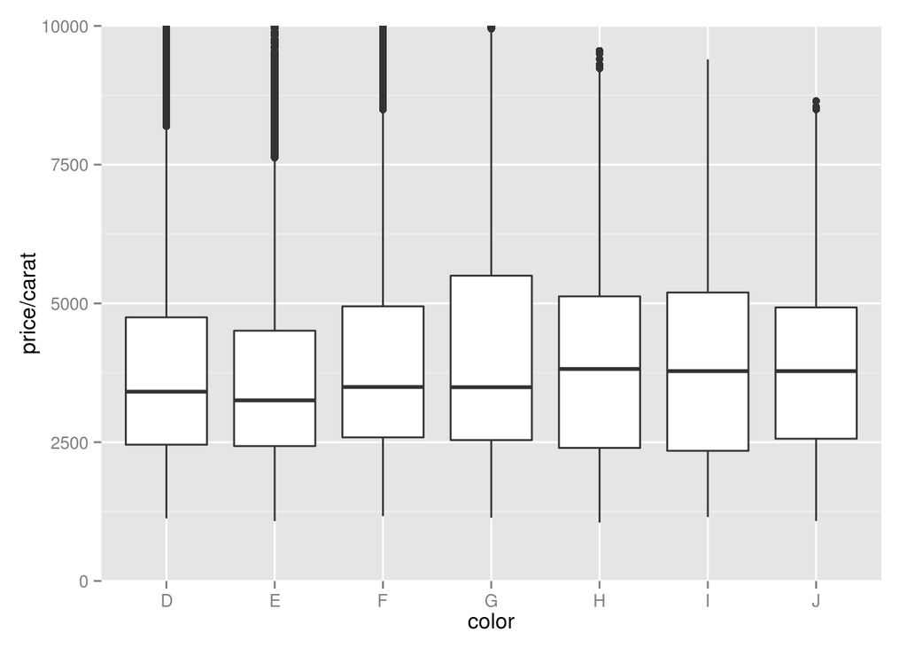

```r
qplot(x = color, y = price/carat, data = diamonds,
      geom = 'boxplot') +
  coord_cartesian(ylim=c(0,10000))
```

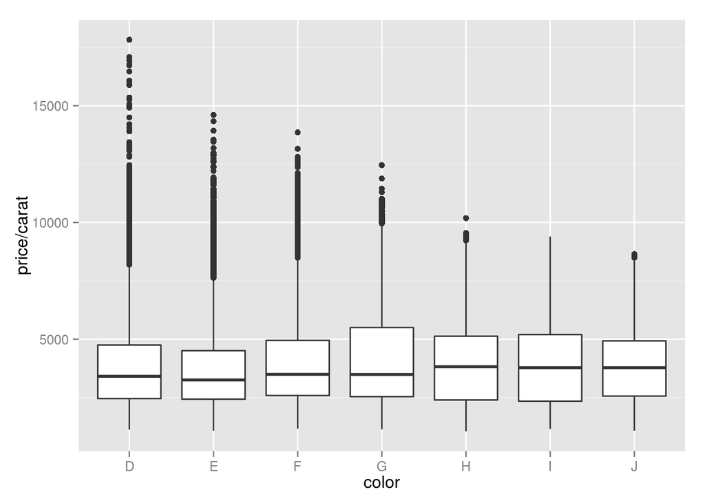

```r
qplot(x = color, y = price/carat, data = diamonds,
      geom = 'boxplot')
```

The prices/carat don’t show a significant difference by color. The better colors have, however, more and higher outliers.

#### Subset data for the middle 50% diamonds carats:

```r
summary(diamonds$carat)
```

```
##    Min. 1st Qu.  Median    Mean 3rd Qu.    Max.
##  0.2000  0.4000  0.7000  0.7979  1.0400  5.0100
```

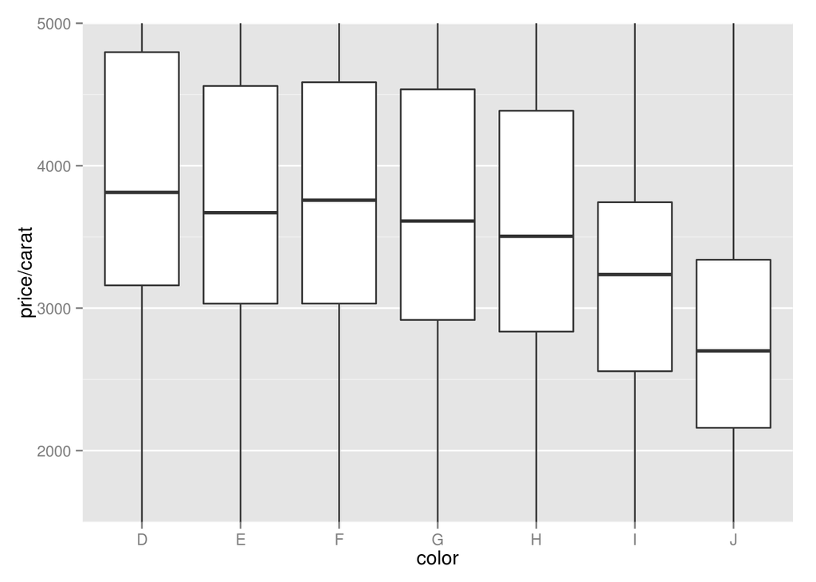

```r
subset.diamonds <- subset(diamonds, carat > 0.4 & carat < 1.05)

qplot(x = color, y = price/carat, data = subset.diamonds,
    geom = 'boxplot') +
  coord_cartesian(ylim=c(1500,5000))
```

Looking only at the diamonds in the middle 50% carats, the difference in price by color is more visible.

### Carat Frequency Polygon

Investigate the weight of the diamonds (carat) using a frequency polygon. Use different bin widths to see how the frequency polygon changes.  
What carat size has a count greater then 2000 ?

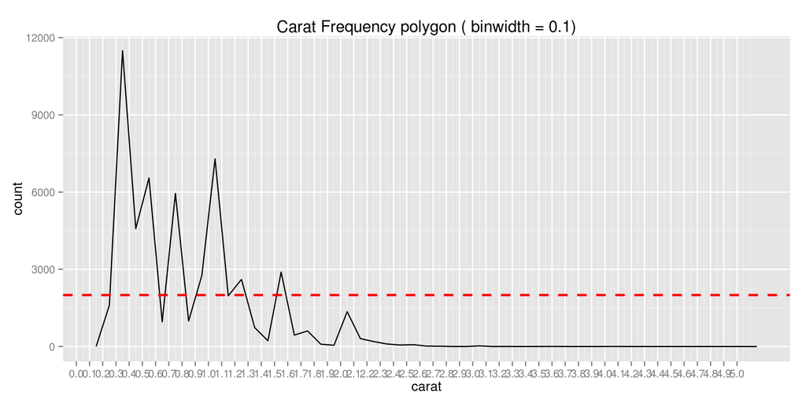

```r
qplot(x = carat, data = diamonds, geom = 'freqpoly', binwidth = 0.1,
      main = "Carat Frequency polygon ( binwidth = 0.1)") +
  scale_x_continuous(breaks = seq(0,5,.1)) +
geom_abline(intercept = 2000, slope = 0, color = 'red', size = 1, lty = 'dashed')
```

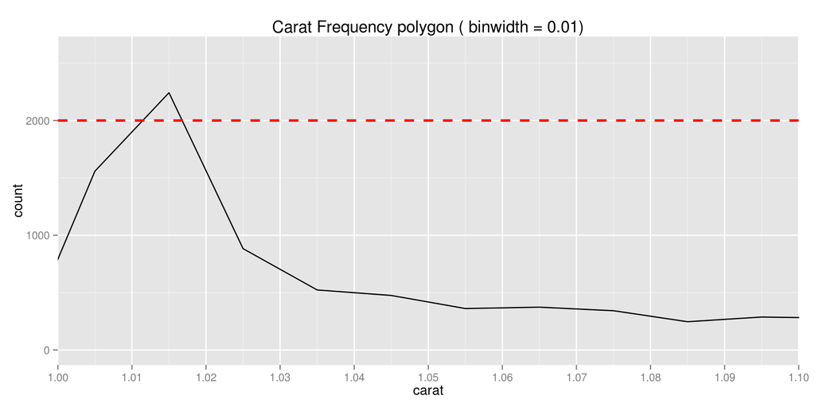

```r
qplot(x = carat, data = diamonds, geom = 'freqpoly', binwidth = 0.01,
      main = "Carat Frequency polygon ( binwidth = 0.01)") +
  scale_x_continuous(breaks = seq(1,1.1,.01)) +
  coord_cartesian(xlim=c(1,1.1))+
geom_abline(intercept = 2000, slope = 0, color = 'red', size = 1, lty = 'dashed')
```

#### What carat size has a count greater then 2000 ?

0.3, 1.01 (in exercise)

Sara Carvalho  
19-02-2015